# Introdução ao R

Priscilla de Abreu Lopes

Novembro, 2016

# Visão Geral

## O que é `R`?

Muitos definem R como um software estatístico. No entanto, a definição dos desenvolvedores vai além:

> *`R` é um ambiente de programação com um conjunto integrado de ferramentas de software para manipulação de dados, simulação, cálculos e exibição de gráficos.* (R Core Team 2016)

Baseado na linguagem `S`, `R` foi desenvolvido no final da década de 90;

`R` pode ser baixado e distribuído gratuitamente de acordo com a licença GNU;

`R` é uma linguagem:

- Interpretada:
  - Interpretador em linha de comando;
  - Desenvolvimento baseado em scripts;
- Tipagem dinâmica;
- Orientada a Objetos;
- Extensível:
  - 25 pacotes com funções básicas;
  - 9500+ pacotes disponíveis no [repostório oficial](https://cran.r-project.org/web/packages/available_packages_by_name.html);

**Instalar o `R`:** Acesse o site do [projeto](https://cran.r-project.org/) para fazer o download da distribuição que mais lhe agrade (Linux, OS X, Windows) e execute o binário para instalação.

## Interface Gráfica

O `R` conta com uma interface gráfica simples, baseada em janelas, onde podem ser acessados:

- o *R Console*;
- Um editor de scripts;
- Opções que facilitam:
  - Execução de scripts;
  - Instalação de pacotes de extensão.

Existem variados editores de textos e IDEs com suporte para desenvolvimento `R`.

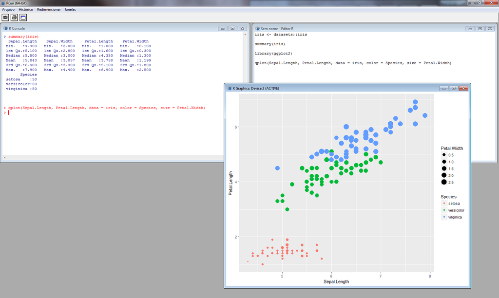

Screenshot da GUI do `R`

### O que é `RStudio`?

O `RStudio` é uma IDE livre e de código aberto, que pode ser executada:

- Localmente (Widnows, OS X e Linux);
- Servidor (Linux).

O `RStudio` tem como objetivo facilitar o desenvolvimento em `R`, contando com:

- Painéis para console, editor de scripts, gráficos, gerenciador de arquivos, entre outros;
- Debugger visual;
- Ferramentas para controle de versão (Paulson 2016);
- Ferramentas de apoio à reprodutibilidade (RStudio Inc. 2016a);
- Framework para aplicações web (RStudio Inc. 2016b).

[figure not shown]

Screenshot do `RStudio`

**Instalar o `RStudio`:** Acesse o site do [`RStudio`](https://www.rstudio.com/products/rstudio/download/) para fazer o download da IDE (Linux, OS X, Windows) e execute o binário para instalação.